# Introduction to lcars

## Making a static plot

This examples adds an LCARS-style border around a static plot. Keep in mind that while the `lcars_border()` function below takes a ggplot object, the result is not a returnable ggplot object. The function uses the `grid` package underneath the hood and draws the necessary elements using viewports.

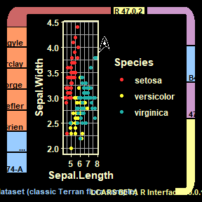

```r
library(lcars)
library(trekcolors)
library(ggplot2)
library(grid)
library(png)

logo <- rasterGrob(readPNG(system.file("stlogo-white.png", package = "lcars")))
clrs <- c("#FF3030", "#FFFF33", "#20B2AA")

g <- ggplot(iris, aes(Sepal.Length, Sepal.Width, color = Species)) +
  geom_point() +
  theme_lcars_dark() +
  coord_cartesian(clip = "off") +
  annotation_custom(logo, xmin = 9.4, xmax = Inf, ymin = 3.6, ymax = Inf) +
  scale_color_manual(values = clrs)

len_frac <- c(0.55, 0.25, 0.2, 0.4, 0.1, 0.2, 0.1, 0.1)
n_seg <- c(1, 2, 0, 8)
corner_colors <- c("chestnut-rose", "lilac", rep("pale-canary", 2))
side_colors <- list("pale-canary", c("anakiwa", "lilac"), NA,
                    c("#000000", rep("anakiwa", 2), rep("orange-peel", 5)))
side_labels <- list(
  "R 47.0.2", c("47", "B4"), NA,
  c("LCARS", "47174-A", "...", "O'Brien", "Lefler", "La Forge", "Barclay", "Argyle"))

lcars_border(g, corners = 1:3, length_frac = len_frac, side_n_segments = n_seg,
             corner_color = corner_colors, side_color = side_colors,
             side_label = side_labels, label_size = 0.7)

text(2.8, 0.1, "Iris dataset (classic Terran flora sample)",
     col = lcars_colors("anakiwa"), font = 2, cex = 0.7)
text(7.55, 0.1, "LCARS BETA R Interface v0.0.1",
     col = lcars_colors("pale-canary"), font = 2, cex = 0.7)
```

As you can see, a decent plot is still going to take some customization with additional commands in order to give it the level of polish it deserves.

But this is just the appetizer; next is the Shiny version.

## LCARS in Shiny

In the `lcars` package, functions whose names are lowercase and contain underscores deal with general R use. Functions whose names use camel case are related to Shiny.

First, use `lcarsPage()` to set up the Shiny UI. This is a wrapper around Shiny’s `bootstrapPage()`. It loads the required CSS and other assets.

There are several functions you can explore. There are a handful of simple wrappers around various Shiny inputs that give them an LCARS aesthetic, but not many currently and they will continue to be improved upon in subsequent package versions.

The primary function of interest is `lcarsBox()`. This is the container that captures the LCARS style. Additional functions worth focusing on include `lcarsHeader()` for breaking up sections of the UI; also `lcarsButton()` and `lcarsToggle()`, which in conjunction with `buttonColumn()` produce column inputs that fit well into the sidebars of an `lcarsBox()`.

Here is a simple example.

```r
if (interactive()) {

  ui <- lcarsPage(
    lcarsBox(
      fluidRow(
        column(3,
          h4("Main panel area"),
          HTML("<p>Some paragraph text and <a href='#'>a link</a>
          with LCARS styling.</p>
          <p>Use <code>lcarsPage</code>
          to apply the LCARS theme and <code>lcarsBox</code>
          to draw a characteristic box for framing content.</p>
          <p>Many of the <code>lcarsBox</code>
          properties are configurable.
          See <code>lcars::lcarsApp(\"box\")</code> for a demo</p>")
        ),
        column(9, plotOutput("plot1"))
      ),
      title = "box title",
      left_inputs = buttonColumn(lcarsButton("btn1", "A button"))
    )
  )

  server <- function(input, output) {
    output$plot1 <- renderPlot({
      hist(rnorm(500))
    })
  }

  shinyApp(ui, server)
}
```

## Demo apps

Rather than post lots of code here in a non-interactive package vignette, the best suggestion is to explore the example apps included in the package. The source code is easy to browse in the GitHub repository.

Use `lcarsApp` to loads various demo apps:

```r
lcarsApp("demo")
lcarsApp("box")
lcarsApp("sweep")
lcarsApp("toggle")
lcarsApp("elements")
lcarsApp("leaflet")
```

The `box` example is helpful for exploring the many ways you can control the style of an `lcarsBox()`. Here are a couple examples highlighting some of the versatility:

### Corner elbows only

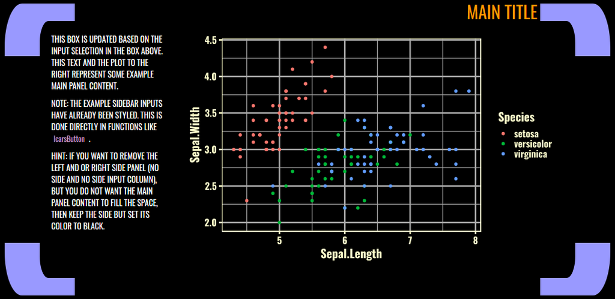

### Colored segments and input panels

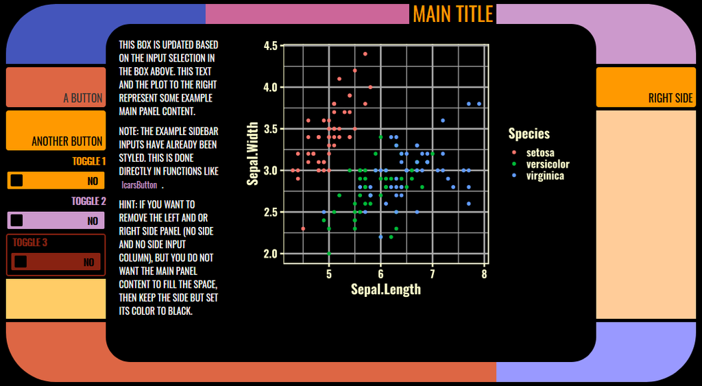

Running these apps will prompt you to install required packages if you do not already have them installed. These are necessary for the examples but not a necessary component of `lcars`, specifically `ggrepel` and `showtext`.

## Recommendations

### Font and casing

Pay attention to the arguments to `lcarsPage()`. Depending on the nature of text content in your app, you may find you need to deviate from some LCARS-style defaults (e.g., uppercase font) to make the text in your app more pleasant to read. It will also allow you to revert to sans serif. It is not an all or nothing switch; you have some control over what to change and what to leave alone.

### Responsiveness limitations

In adhering closely to sizing and layout rules for LCARS UI design, fixed sizing works best for some container widgets like `lcarBox()` and `lcarsSweep()`. You can use settings like `width = "100%"` for these containers, but you may notice limitations in maintaining a responsive UI, particularly when they contain plot outputs. Fixed width widgets are generally recommended.

Visual components such as the LCARS elbow shape underlying some widgets are intended to follow strict sizing and scaling rules. They are not intended to scale arbitrarily or fit well on very small device screens.

### Official LCARS colors

Familiarize yourself with LCARS colors from the `trekcolors` package. This package is a dependency of `lcars`. It includes various other Star Trek color palettes. Most notably it includes a function for previewing the palettes.

There are several generations of LCARS color palettes. The `lcarsdata` dataset in `lcars` provides a convenient data frame of the four main series of LCARS color palettes with official color names, but `trekcolors` offers several helpful functions related to LCARS colors, including LCARS-themed `scale_*` functions for use with `ggplot2`.

```r
head(lcarsdata)
```

```
#>              series         name   value
#> pale-canary    2357  pale-canary #FFFF99
#> tanoi          2357        tanoi #FFCC99
#> golden-tanoi   2357 golden-tanoi #FFCC66
#> neon-carrot    2357  neon-carrot #FF9933
#> eggplant       2357     eggplant #664466
#> lilac          2357        lilac #CC99CC
```

```r
library(ggplot2)
library(trekcolors)

lcars_colors()
```

```
#>      pale-canary            tanoi     golden-tanoi      neon-carrot
#>        "#FFFF99"        "#FFCC99"        "#FFCC66"        "#FF9933"
#>         eggplant            lilac          anakiwa          mariner
#>        "#664466"        "#CC99CC"        "#99CCFF"        "#3366CC"
#>      bahama-blue        blue-bell          melrose          hopbush
#>        "#006699"        "#9999CC"        "#9999FF"        "#CC6699"
#>    chestnut-rose      orange-peel atomic-tangerine            danub
#>        "#CC6666"        "#FF9966"        "#FF9900"        "#6688CC"
#>           indigo  lavender-purple           cosmic       red-damask
#>        "#4455BB"        "#9977AA"        "#774466"        "#DD6644"
#>   medium-carmine          bourbon      sandy-brown       periwinkle
#>        "#AA5533"        "#BB6622"        "#EE9955"        "#CCDDFF"
#>      dodger-pale      dodger-soft        near-blue        navy-blue
#>        "#5599FF"        "#3366FF"        "#0011EE"        "#000088"
#>             husk             rust        tamarillo
#>        "#BBAA55"        "#BB4411"        "#882211"
```

```r
lcars_colors("melrose")
```

```
#>   melrose
#> "#9999FF"
```

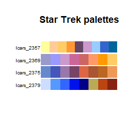

```r
view_trek_pals(c("lcars_2357", "lcars_2369", "lcars_2375", "lcars_2379"))
```

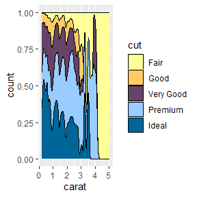

```r
ggplot(diamonds, aes(carat, stat(count), fill = cut)) +
  geom_density(position = "fill") + scale_fill_lcars("2357")
```

Functions in `lcars` that accept color arguments will take any hex color, but will also accept official LCARS colors by name.